# DMII

Ana Catarina Monteiro, Artur Ferreira, Lucas Parada

4/25/2020

# Introdução

Este projeto tem como objetivo a comparação do desempenho de diferentes estratégias de recomendação de filmes a um conjunto de utilizadores, tendo como base um conjunto de dados obtidos através do Flixter, um site onde é possível a partilha de classificações de filmes. Através do mesmo, torna-se possível descobrir novos filmes, baseados nos gostos semelhantes de outros utilizadores.

Os respetivos dados contêm informações relativas às classificações dadas por cada utilizador a um dado filme, assim como a respetiva identificação de ambos e data da sua ocorrência (esta classificação é atribuída com base numa escala numérica que compreende valores de zero a cinco, variando de meio em meio valor) e ainda, informações relativas aos filmes do site: nome e id, bem como as de cada utilizador. Este último englobando dados como o id do utilizador e outras informações que o caracterizam, tais como género, idade, localização, data de login e o tempo relativo ao último acesso ao site.

Numa primeira fase, foi realizada a importação dos dados, assim como a sua respetiva análise exploratória e pré-processamento. Posto isto, procedeu-se à aplicação de diferentes modelos de recomendação, recorrendo a informações binárias e não-binárias relativas às classificações dadas para um conjunto de filmes, visando assim a recomendação de um top N de filmes para um conjunto de utilizadores. Por fim, comparam-se os resultados obtidos em diferentes modelos assim como diferentes top N’s (1,2,5) de recomendações. Foi realizada ainda a análise desses resultados tendo em conta informações adicionais relativas a cada utilizador, como idade e género.

# Definição do problema

Num site cujo maior objetivo é a partilha de filmes e classificação dos mesmos, torna-se essencial que cada utilizador consiga obter recomendações de novos filmes, baseadas em gostos e avaliações semelhantes de outros utilizadores. Para isso, é essencial a criação de sistemas de recomendação que garantam ao máximo esses resultados. Ainda assim nem todos os sistemas apresentam conclusões iguais, os quais iremos avaliar ao longo deste relatório.

# Análise exploratória de dados e etapas de pré-processamento

Inicialmente realizámos a importação dos dados para o formato que considerámos mais apropriado, visando facilitar a sua limpeza, pré-processamento e posterior análise. Para tal, começámos por importar os dados utilizando a biblioteca Pandas do python, uma vez que sabíamos como aplicar estas operações na dita linguagem, transformando o encode para UTF-8 e recorrendo à função ‘html.unescape’ convertemos o html em texto normal. Por fim exportámos os dataframes para ficheiros em formato csv.

Posteriormente, elegemos o DataFrame do R para proceder à restante manipulação dos dados, visto estarmos mais familiarizados com a matéria lecionada durante as aulas.

Desta forma, através da função ‘summary’, conseguimos observar algumas informações genéricas relativas aos conjuntos de dados ‘movies’, ‘profiles’ e ‘ratings’ respetivamente, onde pudemos observar nomeadamente diferentes dados estatísticos relativos à distribuição das variáveis nos conjuntos de dados assim como a existência de missing values. Mais tarde, identificámos *missing values* presentes em alguns parâmetros, tal como podemos observar nas tabelas abaixo, os quais tratámos isoladamente.

Summary de movies

```
##   moviename            movieid
##  Length:66730       Min.   :    1
##  Class :character   1st Qu.:16683
##  Mode  :character   Median :33366
##                     Mean   :33366
##                     3rd Qu.:50048
##                     Max.   :66730
```

Summary de profiles

```
##      userid           gender             location        memberfor
##  Min.   :      1   Length:1002796     Min.   :   0.0   Min.   :1900-01-01
##  1st Qu.: 250830   Class :character   1st Qu.: 188.0   1st Qu.:2009-06-01
##  Median : 548024   Mode  :character   Median : 262.0   Median :2009-09-01
##  Mean   : 536170                      Mean   : 374.6   Mean   :2003-04-10
##  3rd Qu.: 798766                      3rd Qu.: 582.0   3rd Qu.:2009-10-01
##  Max.   :1049511                      Max.   :1617.0   Max.   :2009-12-03
##                                       NA's   :203      NA's   :203
##    lastlogin         profileview          age
##  Min.   :     0.0   Min.   : 12.00   Min.   : 12.00
##  1st Qu.:     4.0   1st Qu.: 21.00   1st Qu.: 21.00
##  Median :     8.0   Median : 25.00   Median : 25.00
##  Mean   :    37.3   Mean   : 27.39   Mean   : 27.39
##  3rd Qu.:    21.0   3rd Qu.: 31.00   3rd Qu.: 31.00
##  Max.   :177278.0   Max.   :113.00   Max.   :113.00
##  NA's   :57925      NA's   :255618   NA's   :255618
```

Summary de ratings

```
##      userid           movieid          rating           date
##  Min.   :      6   Min.   :    1   Min.   :0.500   Min.   :1941-12-07
##  1st Qu.: 238071   1st Qu.:16532   1st Qu.:3.000   1st Qu.:2007-04-07
##  Median : 558113   Median :34422   Median :3.500   Median :2007-10-07
##  Mean   : 544172   Mean   :33553   Mean   :3.613   Mean   :2007-12-26
##  3rd Qu.: 840680   3rd Qu.:51694   3rd Qu.:4.500   3rd Qu.:2008-09-29
##  Max.   :1049508   Max.   :66726   Max.   :5.000   Max.   :2009-11-17
```

Desta forma, o atributo data dos datasets ‘Profiles’ e ‘Ratings’ passa a estar atualizado e em conformidade.

```
## [1] "Nº de utilizadores 147563"
```

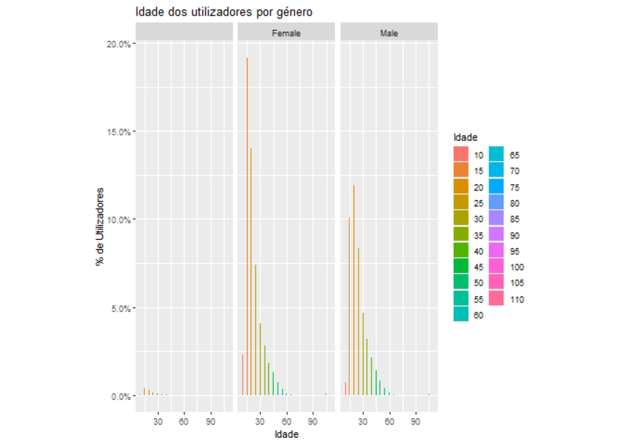

No caso da figura que se segue conseguimos observar a distribuição de ratings, medindo a percentagem para cada nível de classificação.

```
## [1] "Nº de avaliações 8193079"
```

[figure not shown]

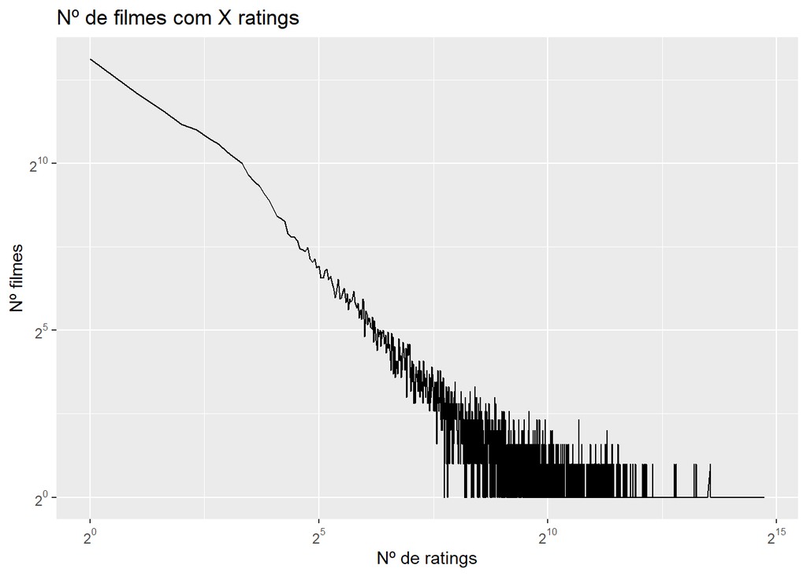

Posto isto decidimos remover filmes com menos de dez e mais de mil e vinte e quatro classificações tendo em vista garantir a relevância dos filmes entre os utilizadores, ou seja, partindo do princípio que um filme com pouca interatividade apresenta uma menor probabilidade de ser recomendado e vice-versa.

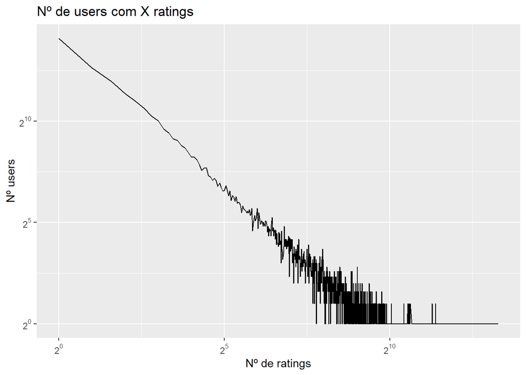

Concluindo, podemos agora observar a distribuição de idades e géneros por utilizador assim como a variação de classificações, com os dados já processados, tal como indicam as próximas duas figuras.

```
## [1] "Nº de filmes 5980"
```

```
## [1] "Nº de utilizadores 3286"
```

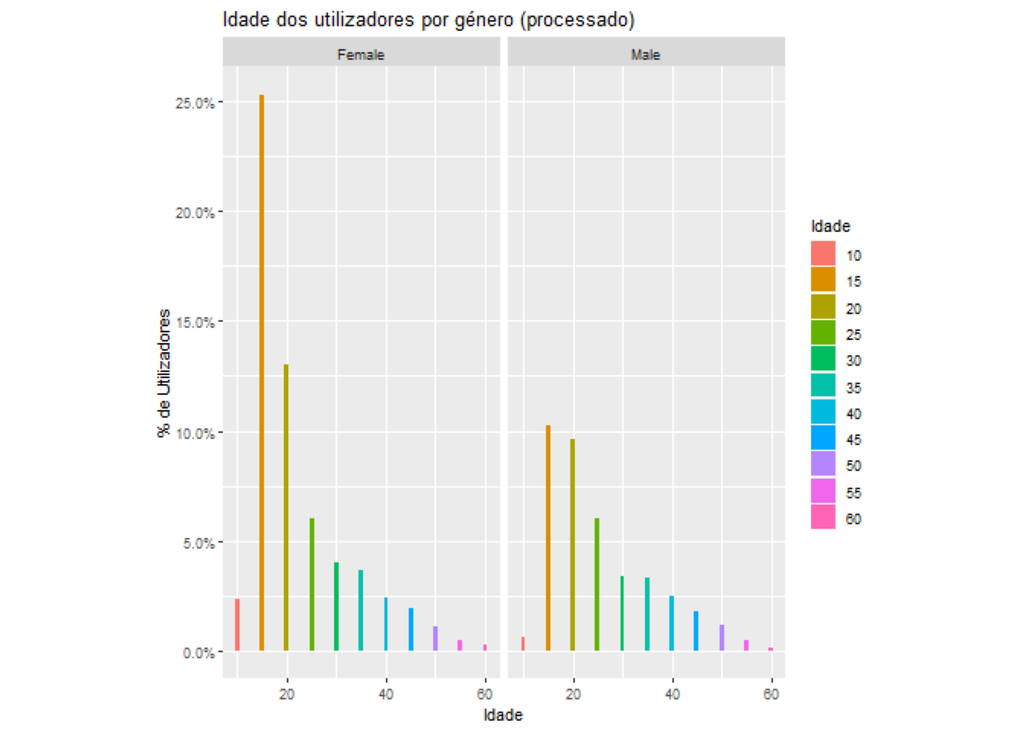

```
## [1] "Nº de avaliações 41047"
```

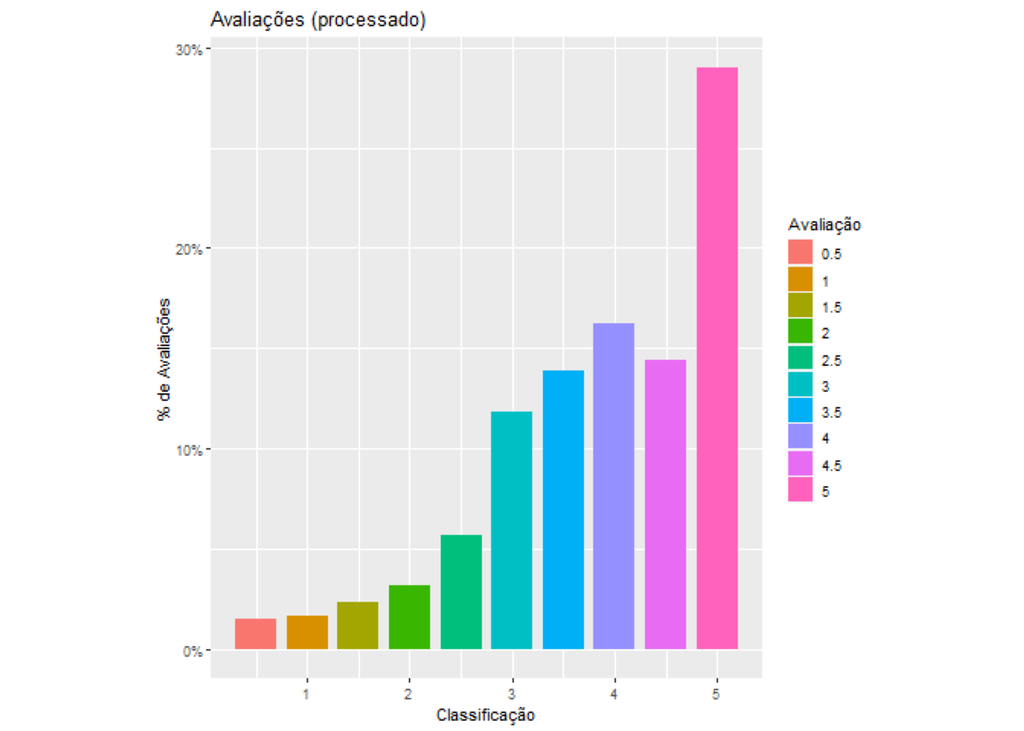

# Sistemas de Recomendação

No que concerne aos sistemas de recomendação, foram abordados neste projeto quatro algoritmos distintos: Popularidade, Regras de Associação (AR), e Collaborative Filtering, sendo este último composto por User-Based (UBCF) e Item-Based (IBCF).

Começámos por criar duas funções distintas, capazes de calcular as recomendações pretendidas, tendo em conta informações relativas às classificações dadas pelos utilizadores: binárias, para os modelos mencionados acima e não binárias, este último aplicado somente ao UBCF e IBCF. Em ambos os casos utilizámos a função ‘evaluationScheme’ para dividir o conjunto de dados em treino e teste e definimos os parâmetros que cada algoritmo requer assim como executar os modelos para top N(1, 2 e 5).

## Sem contexto

### Recomendações de filmes

Para aplicar os modelos mencionados, começámos por desconsiderar informações que caracterizam cada utilizador, e criámos a matriz binária que correlaciona os utilizadores e os filmes (figura abaixo).

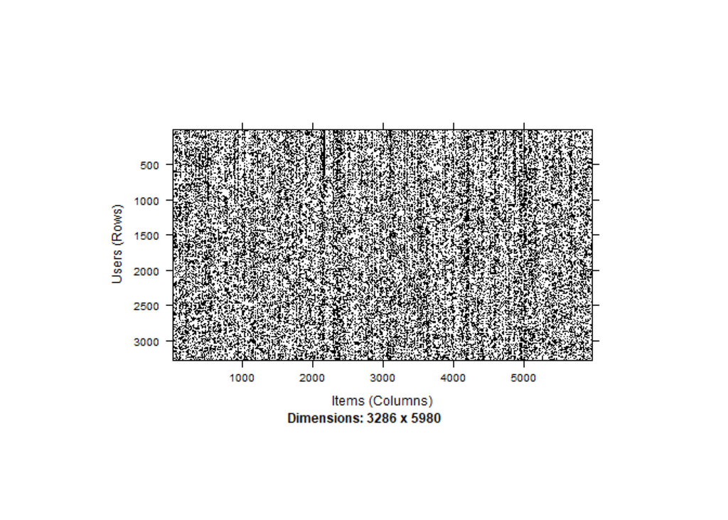

Relativamente às regras de associação escolhemos um suporte de 0.01, para evitar a escassez de regras, no entanto, definimos a confiança a 0.8 tendo em vista garantir a fiabilidade das mesmas. Definimos ainda o comprimento máximo das regras como cinco, uma vez que considerámos um mínimo de dez filmes avaliados por utilizador e tendo em conta que, no máximo, serão recomendados cinco filmes. Já no caso dos algoritmos UBCF e IBCF, definimos os *nearest-neighbours* a três para evitar que, na hipótese de escolher um número maior, os algoritmos não fizessem recomendações com vizinhos que, na verdade, não se mostram assim tão semelhantes.

Deste modo podemos observar os dados obtidos através da seguinte figura:

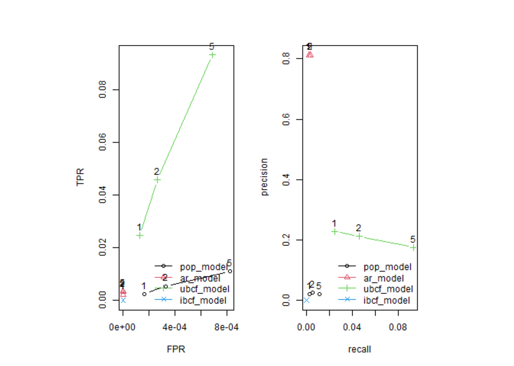

### Prever os ratings

No que diz respeito à previsão das classificações por parte dos utilizadores recorremos apenas aos algoritmos de UBCF e IBCF, visto que os restantes (Popularidade e Regras de Associação), não são válidos no que concerne aos objetivos desta tarefa. Os parâmetros utilizados são, portanto, iguais aos utilizados na recomendação de filmes, pelos mesmos motivos explicados anteriormente. Na figura abaixo podemos observar a matriz de avaliações para um conjunto limitado de pessoas e filmes.

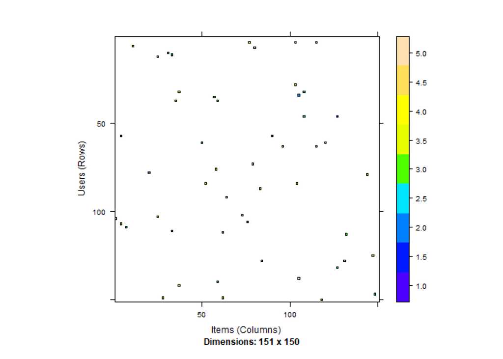

Relativamente à avaliação dos modelos gerados, considerámos como sendo uma boa pontuação valores iguais ou superiores a três, tendo em conta que os dados de treino, classificações dadas e parâmetros dos modelos são iguais aos dados das recomendações de filmes. Podemos observar, portanto, os resultados obtidos, na próxima figura.

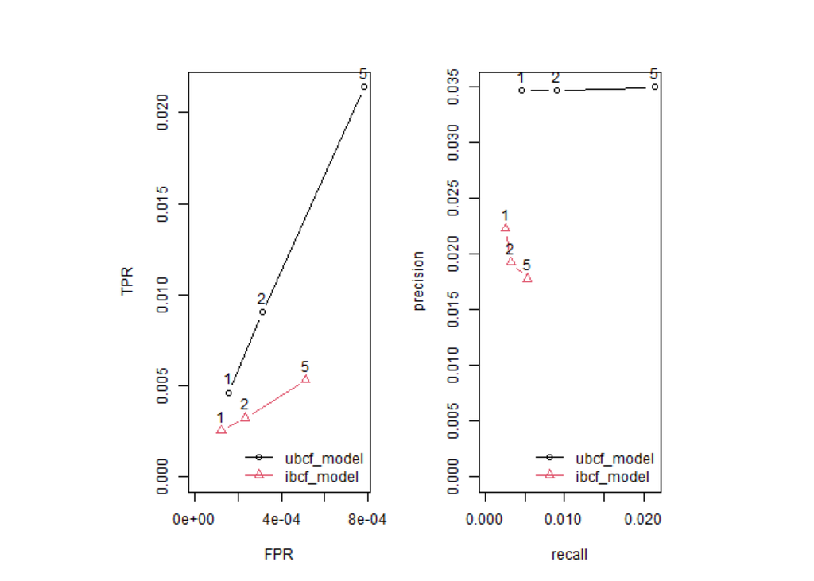

No que toca à previsão dos ratings, mais uma vez, o modelo UBCF destacou-se em comparação ao IBCF, apresentando os melhores resultados de *precision* e *recall* à medida que as recomendações aumentam. Por outro lado, observando o comportamento do algoritmo IBCF, reparamos que a métrica *precision* diminui à medida que aumentam as recomendações, apesar do *recall* ser muito semelhante em todos os casos. Relativamente aos valores obtidos em TPR e FPR, ambas as métricas aumentam nos dois modelos, à medida que aumenta o número de recomendações, no entanto o aumento no TPR é mais significativo no UBCF do que no IBCF.

## Com contexto

Tendo agora em conta características relevantes de cada utilizador, filtrámos os dados utilizados nos modelos para aferir novos resultados. Neste caso, considerámos como sendo as características mais relevantes a idade e género dos utilizadores sendo o intervalo predominante compreendido entre quinze a vinte anos em ambos os géneros e ainda tendo em conta apenas o intervalo referido da idade, isto é, ignorando o género. Já nos parâmetros, uma vez consideramos agora atributos relevantes dos utilizadores, aumentámos o valor de *nearest-neighbours* para cinco. Assim, o objetivo passa por observar possíveis mudanças na performance dos modelos, atendendo às alterações efetuadas.

### Recomendações de filmes

Observamos, deste modo, os resultados obtidos tendo em conta apenas o intervalo de idades entre quinze a vinte anos.

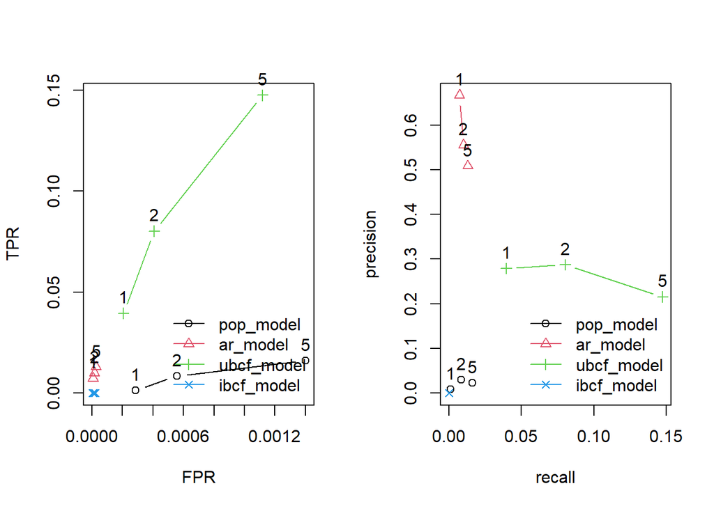

Os resultados destes modelos mostraram-se muito semelhantes aos observados aquando da aplicação dos mesmos excluindo a consideração de contexto, ainda assim o TPR mostrou-se mais alto.

De seguida, apresentamos os resultados aplicados ao mesmo intervalo de idades, mas tendo em conta, agora, o género feminino.

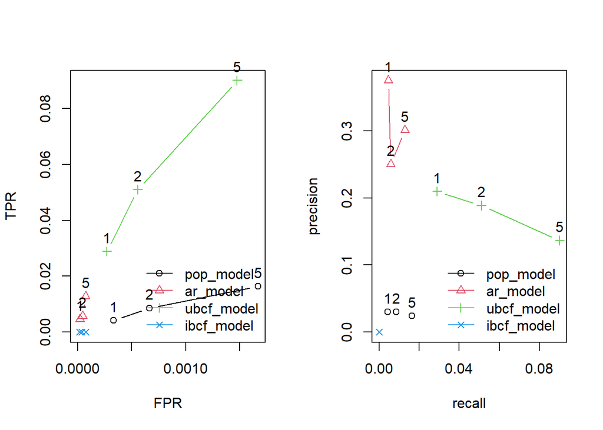

Já considerando o género feminino, os valores voltam a assemelhar-se aos obtidos nas recomendações sem contexto.

Finalmente, obtemos os resultados concernentes de novo ao mesmo intervalo de idades, mas para os utilizadores de género masculino.

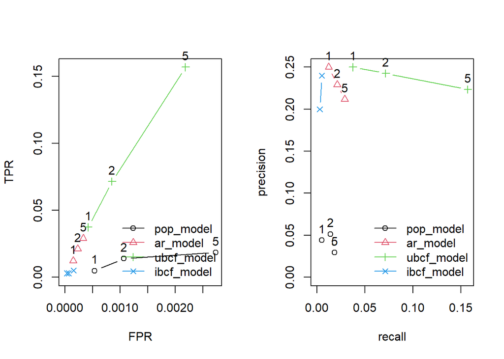

# Conclusão

Após o término deste projeto tornou-se claro que o modelo UBCF é o que apresenta os melhores resultados, para o problema proposto. Podemos também concluir que, de facto, usar os atributos dos utilizadores como contexto tende a amplificar a eficácia dos resultados.

Relativamente à filtragem de dados que efetivámos, desconsiderámos as datas que separam os ratings, uma vez que os mesmos apresentam um intervalo de três anos, o qual considerámos pouco relevante. Ainda assim, sentimos que teria sido proveitoso realizar uma análise com uma maior quantidade de dados, no entanto, o hardware disponível não se mostrou capaz de executar os modelos em tempo útil.

Um dos tópicos não abordados foi a verificação da eficácia dos modelos construídos para um grupo específico, ainda assim trata-se de algo que futuramente iremos testar.